# Speech Input Block

August 13, 2019

# 1 Data Parsing

## 1.1 Loading Data

Filtering out invalid participants (9, 10, and 14).

```r
data_c = read.csv("parse_more.csv",sep=",") %>% filter(!participantNo %in% c(9, 10, 14))
data_c = data_c[,!names(data_c) %in% c("incorrect_fixed", "fixes", "correct", "inf", "msg", "correctMsg", "gMsg")]
data_c$totalTime = data_c$inputTime + data_c$prepTime
data_c.kbd = filter(data_c, inputType=="Keyboard")
data_c.sr = filter(data_c, inputType=="Speech")

data_t = read.csv("parse_more_trans.csv",sep=",")
data_t = data_t[,!names(data_t) %in% c("incorrect_fixed", "fixes", "correct", "inf", "msg", "orgMsg")]
data_t$totalTime = data_t$inputTime + data_t$prepTime
data_t$setNum = substr(data_t$setNum, 1, 1)
data_t.kbd = filter(data_t, inputType=="Keyboard")
data_t.sr = filter(data_t, inputType=="Speech")
```

## 1.2 Outlier Culling

I removed values outside of 3 standard deviations for the means of each task x method combination, for totalTime.

22 outliers identified for composition (2.04% of trials)

26 outliers identified for transcription (2.32% of trials)

## 1.3 Data Aggregation

Aggregating the cleaned data

```r
data = bind_rows(data_t.clean, data_c.clean)
data$block = cut(data$trialNo, breaks = c(0, 5, 10, 15, 21),
                        labels = c(1, 2, 3, 4))
#c(0, 5, 10, 15, 21)
data.group = summarize(group_by(data, participantNo, inputType, taskType, block), meanInputTime = mean(inputTime), meanPrepTime = mean(prepTime), meanEntryTime = mean(entryTime), meanTotalTime = mean(totalTime), meanLen = mean(msgLen), meanWpm = mean(wpm), mean_uer = mean(uncorrected_error_rate), mean_cer= mean(corrected_error_rate), mean_bd = mean(bandwidth), meanCorrTime = mean(corrTime))

data.stats = data %>%
  group_by(block) %>%
  summarize(mIT = mean(inputTime), cuIT = ci(inputTime)[3], clIT = ci(inputTime)[2], sdIT = sd(inputTime),
            mPT = mean(prepTime), cuPT = ci(prepTime)[3], clPT = ci(prepTime)[2], sdPT = sd(prepTime),
            mET = mean(entryTime), cuET=ci(entryTime)[3], clET = ci(entryTime)[2], sdET = sd(entryTime),
            mTT = mean(totalTime), cuTT = ci(totalTime)[3], clTT = ci(totalTime)[2], sdTT = sd(totalTime),
            mCT = mean(corrTime), cuCT = ci(corrTime)[3], clCT = ci(corrTime)[2], sdCT = sd(corrTime),
            mWpm = mean(wpm), cuWpm = ci(wpm)[3], clWpm = ci(wpm)[2], sdWpm = sd(wpm),
            m_uer = mean(uncorrected_error_rate), cu_uer = ci(uncorrected_error_rate)[3], cl_uer = ci(uncorrected_error_rate)[2], sd_uer = sd(uncorrected_error_rate),
            m_cer= mean(corrected_error_rate), cu_cer = ci(corrected_error_rate)[3], cl_cer = ci(corrected_error_rate)[2], sd_cer = sd(corrected_error_rate),
            m_bd = mean(bandwidth), cuBD = ci(bandwidth)[3], clBD = ci(bandwidth)[2], sdBD = sd(bandwidth))

data.long = melt(data.group, id = c("participantNo", "inputType", "taskType", "block", "meanInputTime", "meanPrepTime", "meanWpm", "meanTotalTime", "meanEntryTime", "meanLen", "mean_uer", "mean_cer", "mean_bd", "meanCorrTime"))

data.long$participantNo <- factor(data.long$participantNo)
data.long$inputType <- factor(data.long$inputType)

data.long.c = filter(data.long, taskType == "Composition")
data.long.c = data.long.c[,!names(data.long.c) %in% c("taskType")]

data.long.t = filter(data.long, taskType == "Transcription")
data.long.t = data.long.t[,!names(data.long.t) %in% c("taskType")]

#data.long$setNum <- factor(data.long$setNum)
data.long$block <- factor(data.long$block)
data.long$taskType <- factor(data.long$taskType)
#
# data.long.c$setNum <- factor(data.long.c$setNum)
# data.long.t$setNum <- factor(data.long.t$setNum)
```

Output data stats to a Latex table

Psych, this didn’t actually work that well….

```r
#data.stats.i = unite(data.stats, "ti", taskType, inputType)
#data.stats.i = data.stats.i[order(data.stats.i$ti),]

#data.tbl <- dplyr::select(data.stats.i, ti, mTT, sdTT, mIT, sdIT, mPT, sdPT, mET, sdET, mWpm, sdWpm, m_uer, sd_uer, m_cer, sd_cer) %>% t %>% as.data.frame()

#print(xtable(data.tbl, type = "latex"), file = "autogen/table.tex")
```

# 2 Input Time

## 2.1 Effects of Input Type, Task Type, and Block

### 2.1.1 Normality Check

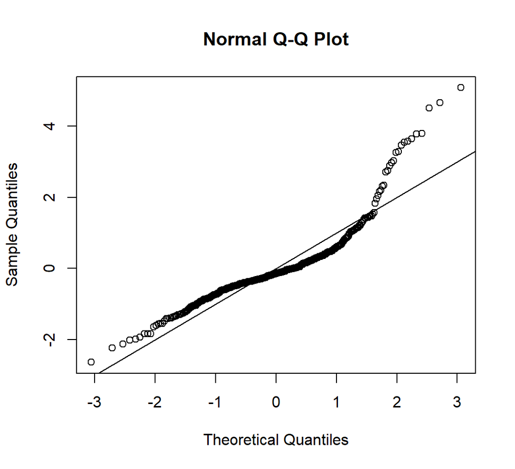

```r
m <- aov(meanInputTime ~ taskType*inputType*block, data=data.long)
pander(normalCheck(m))
```

Shapiro-Wilk normality test

data: res W = 0.86444, p-value < 2.2e-16

Shapiro-Wilk normality test: `res`

| Test statistic | P value |
| --- | --- |
| 0.8644 | 2.778e-19 * * * |

The data is not normally distributed.

### 2.1.2 Box-Cox Transformation

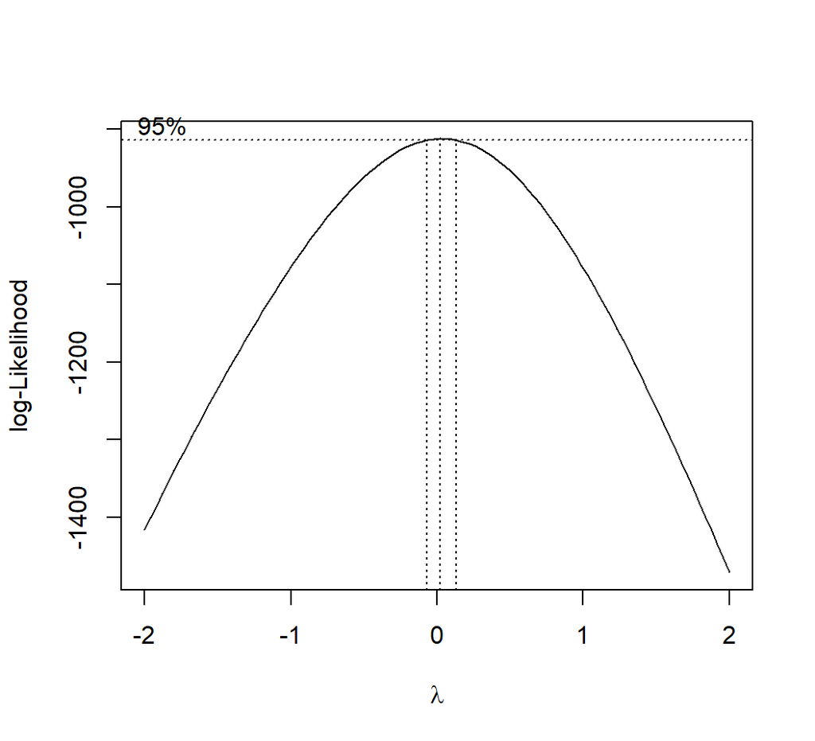

```r
boxcox(meanInputTime ~ inputType*taskType*block, data=data.long, plotit=T)
```

An effective lambda value is 0.0 (a.k.a, a log transformation).

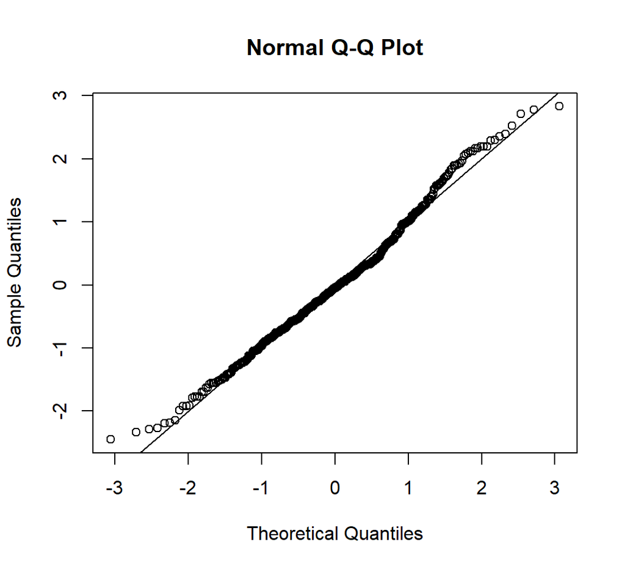

```r
datatr = data.long %>%
    mutate(meanInputTime = log(meanInputTime))

m <- aov(meanInputTime ~ taskType*inputType*block, data=datatr)
pander(normalCheck(m))
```

Shapiro-Wilk normality test

data: res W = 0.98987, p-value = 0.003498

Shapiro-Wilk normality test: `res`

| Test statistic | P value |
| --- | --- |
| 0.9899 | 0.003498 * * |

### 2.1.3 Repeated measures ANOVA on transformed data

```r
anova = ezANOVA(datatr, dv=.(meanInputTime), wid=.(participantNo), within=.(inputType,taskType,block), detailed=TRUE)
# kable(anova$`Mauchly's Test for Sphericity`)
# kable(anova$`Sphericity Corrections`)
# kable(anova$ANOVA)
anova_apa = anova_apa(anova, sph_corr ="gg", es = "ges", print=FALSE)
input = anova_apa$text[2]
task = anova_apa$text[3]
kable(anova_apa)
```

| effect | text |
| --- | --- |
| (Intercept) | F(1, 27) = 49870.75, p < .001, getasq > .99 |
| inputType | F(1, 27) = 412.90, p < .001, getasq = .69 |
| taskType | F(1, 27) = 67.33, p < .001, getasq = .20 |
| block | F(3, 81) = 0.52, p = .668, getasq < .01 |
| inputType:taskType | F(1, 27) = 0.20, p = .659, getasq < .01 |
| inputType:block | F(3, 81) = 0.69, p = .563, getasq < .01 |
| taskType:block | F(2.31, 62.25) = 2.00, p = .137, getasq < .01 |
| inputType:taskType:block | F(2.30, 61.98) = 1.47, p = .236, getasq < .01 |

No effect of block, or the interaction of block with taskType and inputType.

### 2.1.4 Post-hoc analysis with Tukey HSD

```r
# attach(datatr)
# pw <- pairwise.t.test(meanInputTime, interaction(inputType, taskType), p.adj = "bonferroni")
# detach(datatr)
# kable(pw$p.value)
```

# 3 Prep Time

## 3.1 Chart

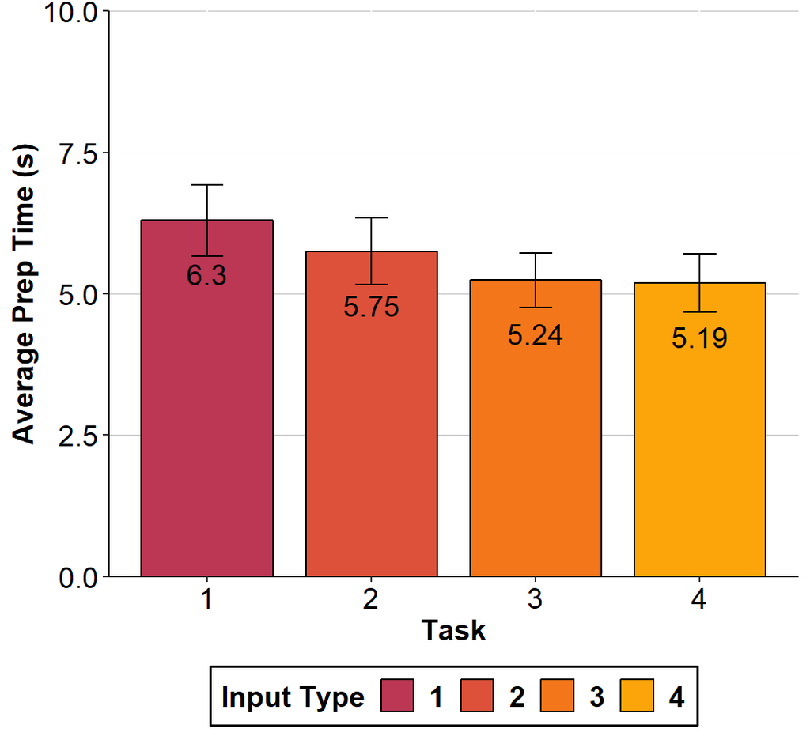

```r
ggplot(data.stats, aes(x=block, y=mPT/1000, fill=block)) +
  geom_bar(aes(group=block), position = position_dodge(.8), colour="black", stat="identity", width=.8) +
  geom_errorbar(aes(ymin = clPT/1000, ymax = cuPT/1000, group= block), width = 0.2, size = .5, position = position_dodge(.8)) +
  geom_text(aes(label=round(mPT/1000,digits=2), group= block), size = 5, position = position_dodge(.8), vjust = 3, alignment="center") +
  scale_x_discrete(name="Task") +
  scale_y_continuous(name="Average Prep Time (s)", limits = c(0, 10), minor_breaks = 5, expand = c(0, 0)) +
  scale_fill_viridis(option="inferno", begin=0.5, end = .8, discrete = TRUE) +
  #scale_fill_manual(values=c("#DF5E28", "#F6C584")) +
  labs(fill = "Input Type") +
  theme(legend.position = "bottom",
        legend.box.background = element_rect(size=1, color="black"),
        legend.background = element_rect(size = 0.3, linetype = "solid", colour = "black"),
        panel.background = element_blank(),
        panel.border = element_blank(),
        axis.line = element_line(),
        axis.title = element_text(family="Helvetica", face="bold", colour="black", size="14"),
        axis.text = element_text(family="Helvetica", colour="black", size="14"),
        panel.grid.major.y = element_line( size = .1, color = "grey"),
        legend.title = element_text(family="Helvetica", face="bold", colour="black", size="14"),
        legend.text = element_text(family="Helvetica", face="bold", colour="black", size="14"))
```

## 3.2 Effects of Input Type, Task Type, and Block

### 3.2.1 Normality Check

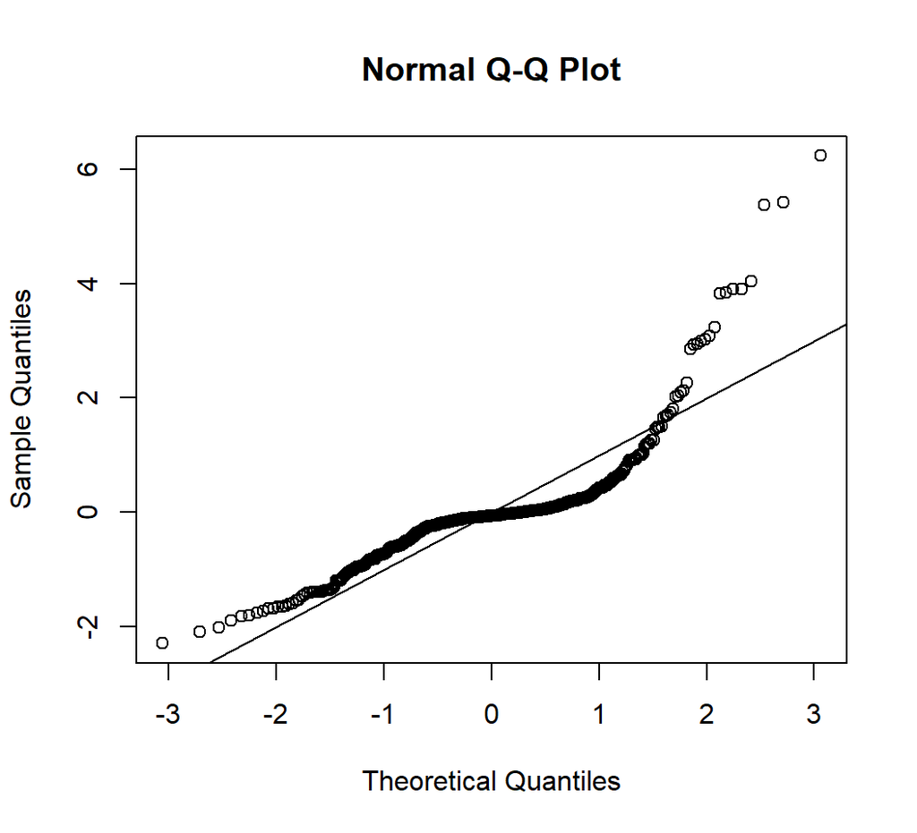

```r
m <- aov(meanPrepTime ~ taskType*inputType*block, data=data.long)
pander(normalCheck(m))
```

Shapiro-Wilk normality test

data: res W = 0.79113, p-value < 2.2e-16

Shapiro-Wilk normality test: `res`

| Test statistic | P value |
| --- | --- |
| 0.7911 | 1.472e-23 * * * |

The data is not normally distributed.

### 3.2.2 Box-Cox Transformation

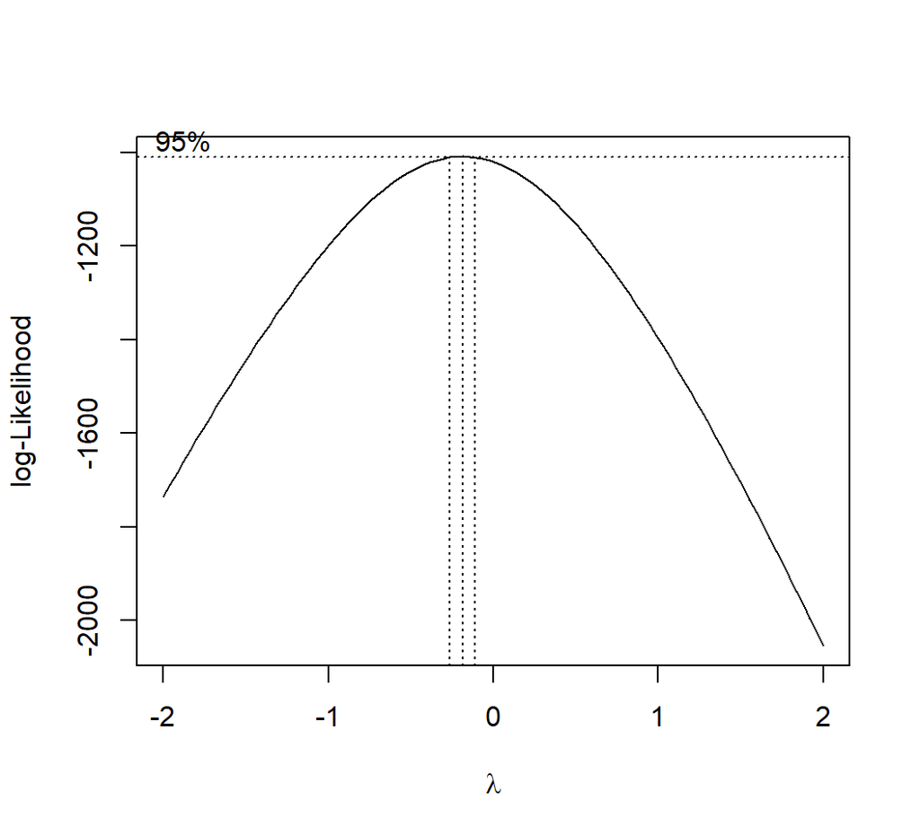

```r
boxcox(meanPrepTime ~ inputType*taskType*block, data=data.long, plotit=T)
```

An effective lambda value is -0.1.

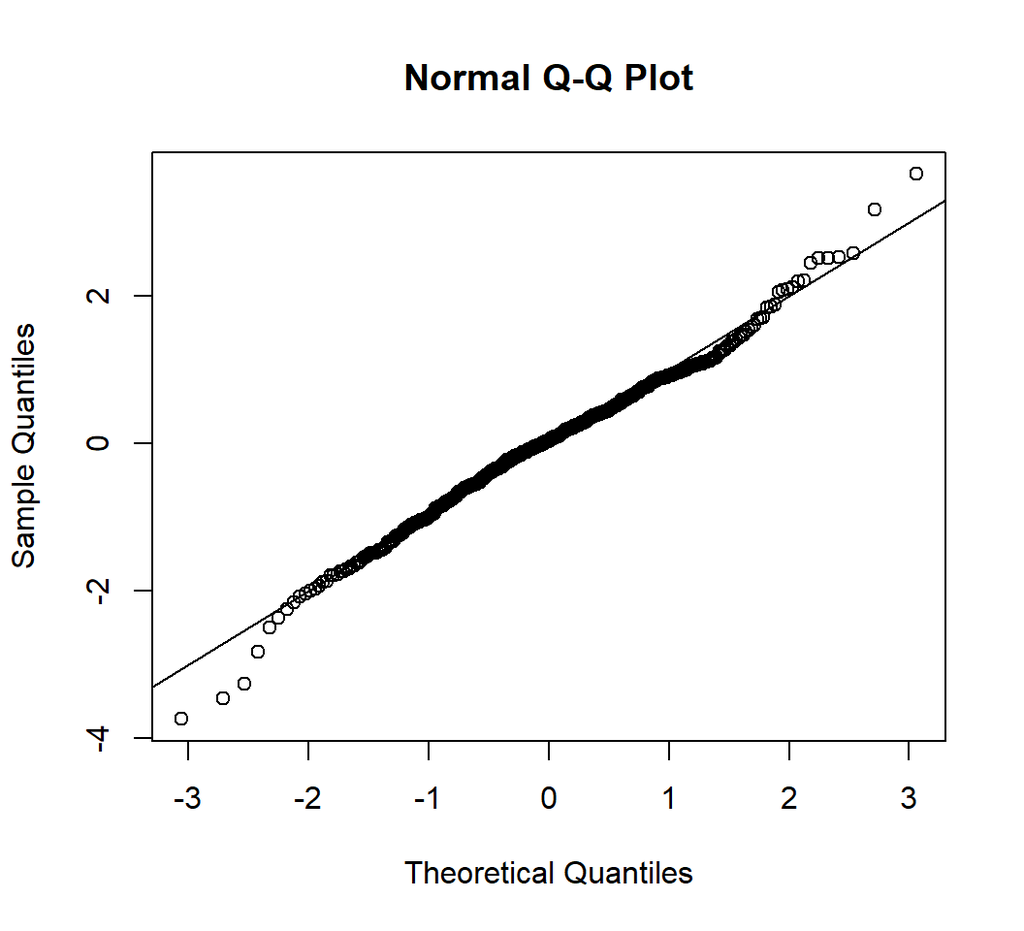

```r
datatr = data.long %>%
    mutate(meanPrepTime = meanPrepTime^(-0.1))

m <- aov(meanPrepTime ~ taskType*inputType*block, data=datatr)
pander(normalCheck(m))
```

Shapiro-Wilk normality test

data: res W = 0.98949, p-value = 0.00268

Shapiro-Wilk normality test: `res`

| Test statistic | P value |
| --- | --- |
| 0.9895 | 0.00268 * * |

### 3.2.3 Repeated measures ANOVA on transformed data

```r
anova = ezANOVA(datatr, dv=.(meanPrepTime), wid=.(participantNo), within=.(inputType,taskType,block), detailed=TRUE)
# kable(anova$`Mauchly's Test for Sphericity`)
# kable(anova$`Sphericity Corrections`)
# kable(anova$ANOVA)
anova_apa = anova_apa(anova, sph_corr ="gg", es = "ges", print=FALSE)
input = anova_apa$text[2]
task = anova_apa$text[3]
kable(anova_apa)
```

| effect | text |
| --- | --- |
| (Intercept) | F(1, 27) = 34353.85, p < .001, getasq > .99 |
| inputType | F(1, 27) = 230.67, p < .001, getasq = .59 |
| taskType | F(1, 27) = 283.05, p < .001, getasq = .67 |
| block | F(3, 81) = 16.12, p < .001, getasq = .02 |
| inputType:taskType | F(1, 27) = 4.92, p = .035, getasq = .02 |
| inputType:block | F(3, 81) = 0.45, p = .720, getasq < .01 |
| taskType:block | F(3, 81) = 1.65, p = .184, getasq < .01 |
| inputType:taskType:block | F(2.39, 64.55) = 1.84, p = .160, getasq < .01 |

Block has an effect, but doesn’t have any interactions with taskType or inputType.

### 3.2.4 Post-hoc analysis with Tukey HSD

```r
t <- TukeyHSD(m)
kable(t$`block`)
```

|  | diff | lwr | upr | p adj |
| --- | --- | --- | --- | --- |
| 2-1 | 0.0037065 | -0.0032588 | 0.0106717 | 0.5173796 |
| 3-1 | 0.0055561 | -0.0014091 | 0.0125213 | 0.1689724 |
| 4-1 | 0.0066552 | -0.0003100 | 0.0136204 | 0.0670800 |
| 3-2 | 0.0018496 | -0.0051156 | 0.0088149 | 0.9028437 |
| 4-2 | 0.0029487 | -0.0040165 | 0.0099140 | 0.6947228 |
| 4-3 | 0.0010991 | -0.0058661 | 0.0080643 | 0.9772085 |

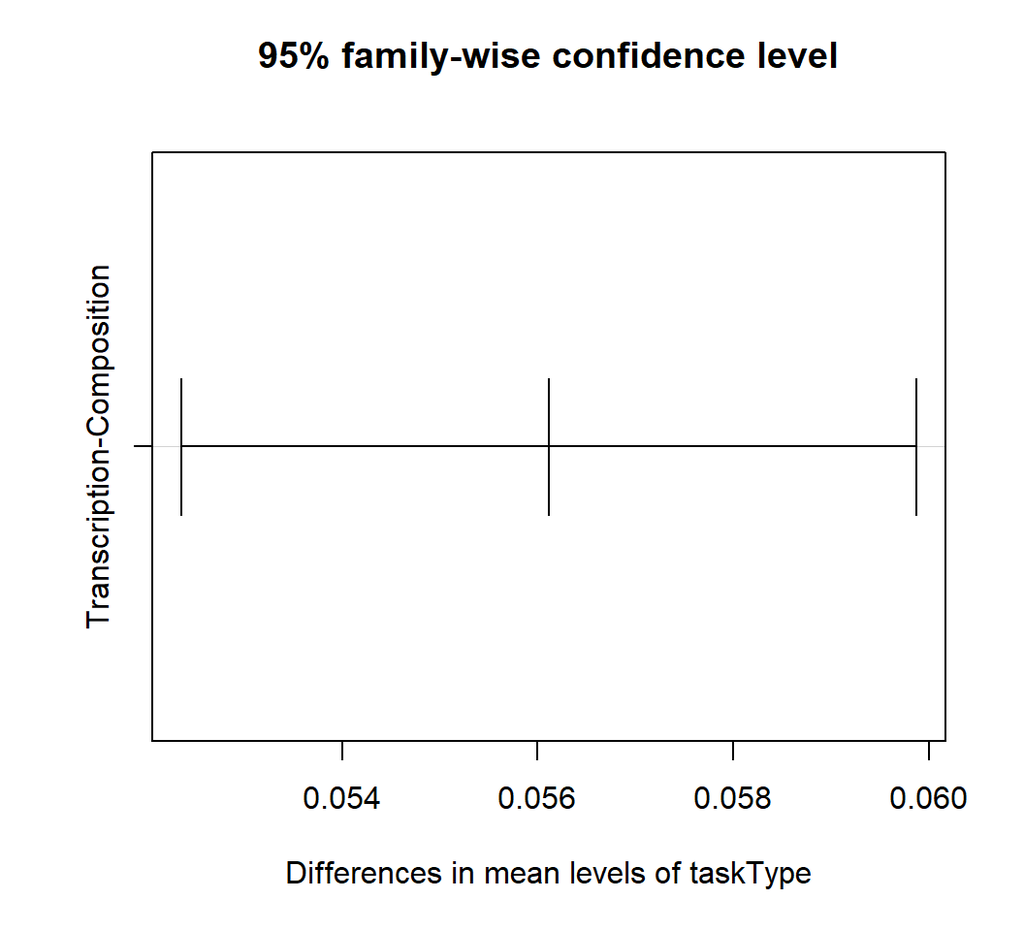

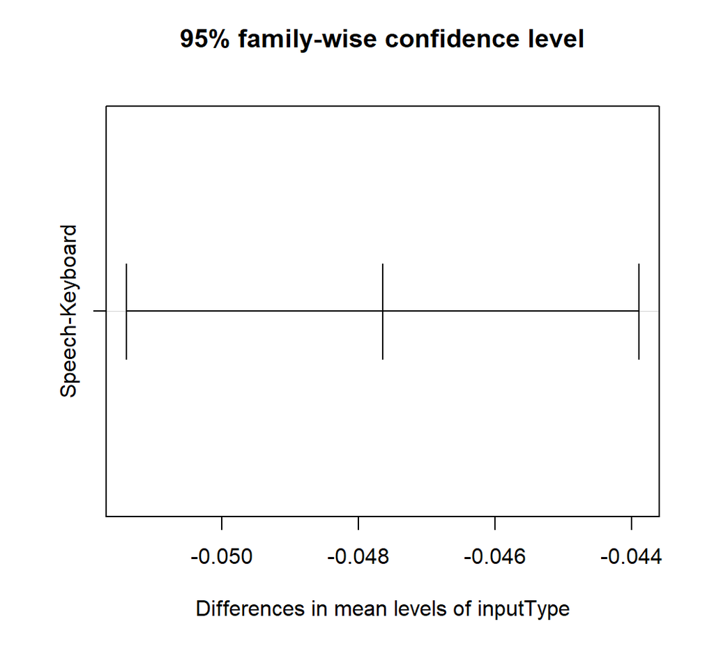

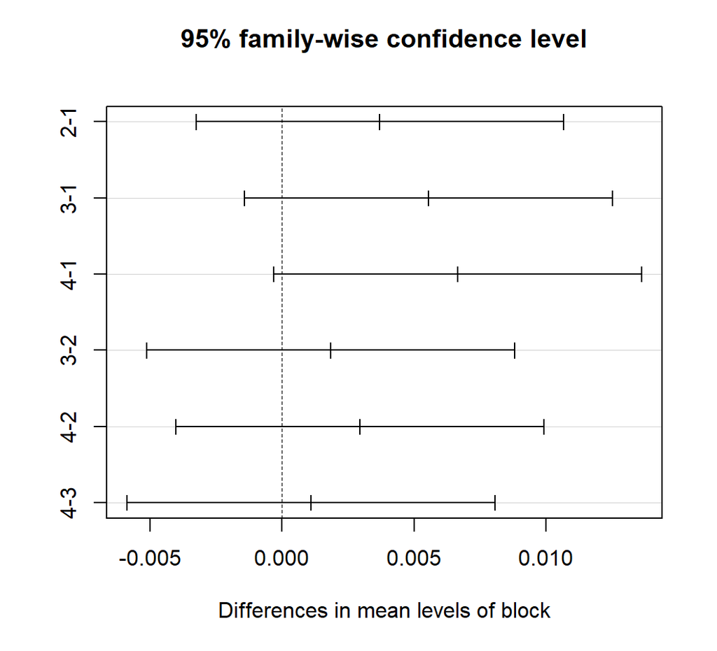

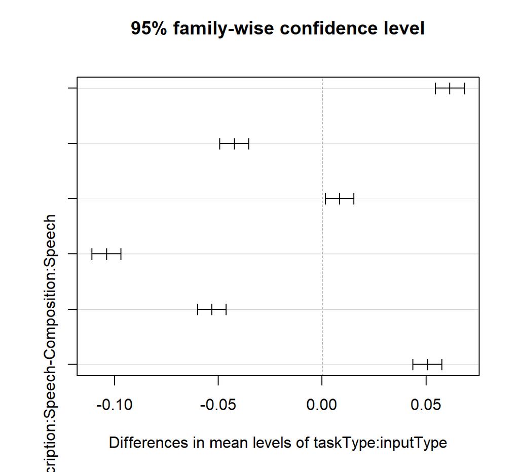

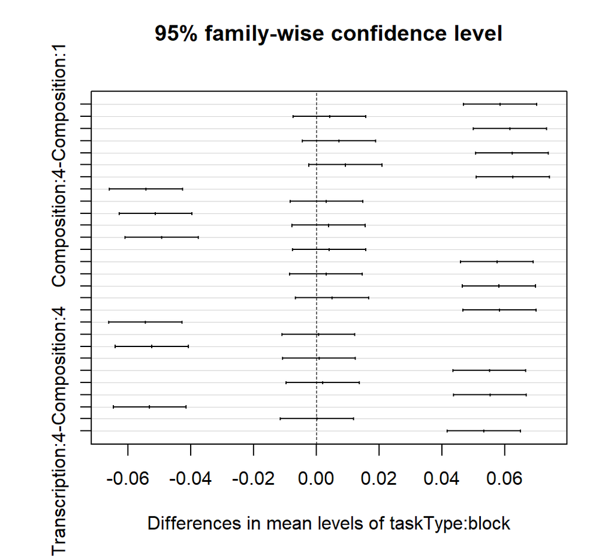

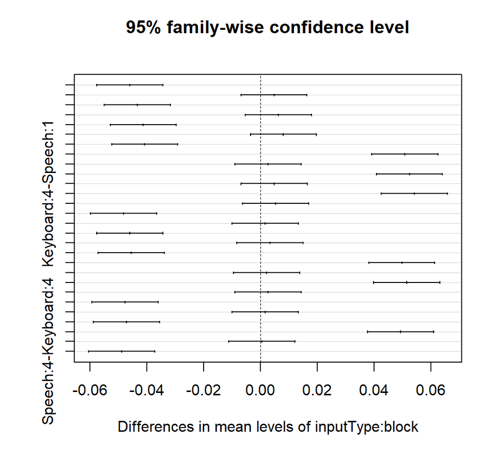

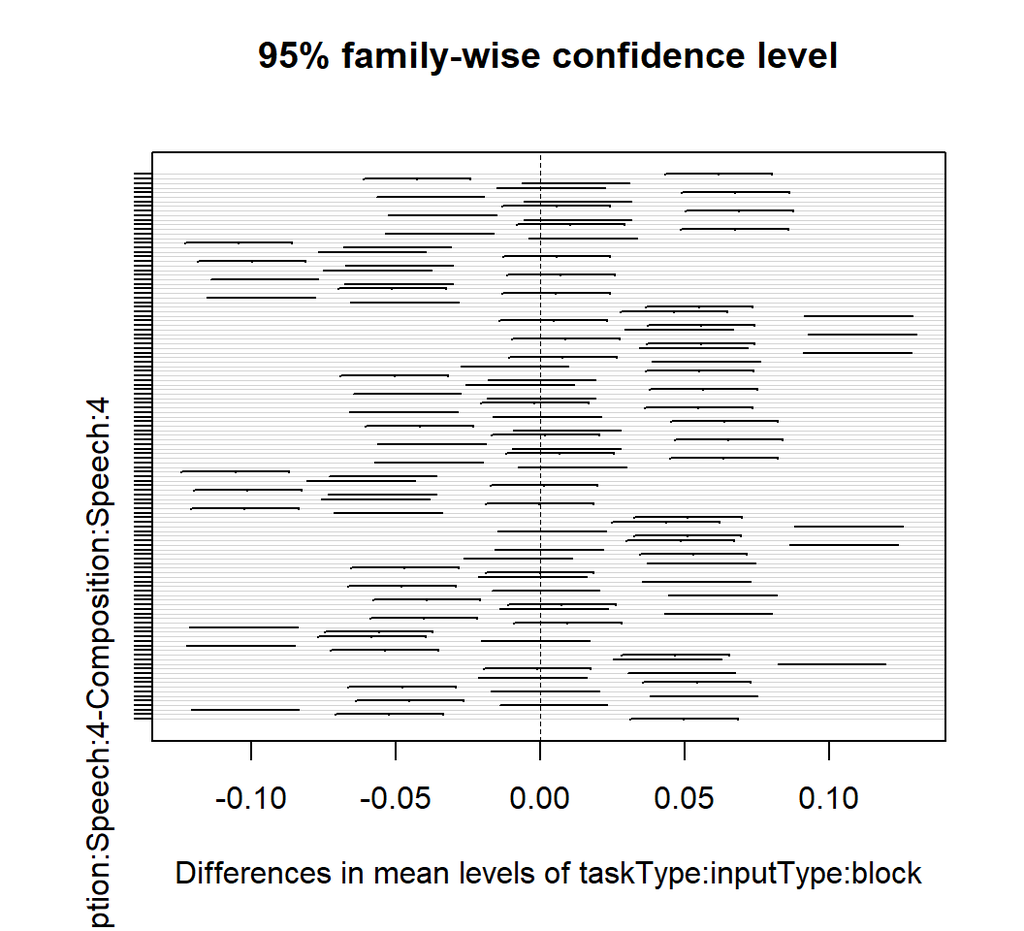

```r
plot(t)
```

# 4 Total Time

## 4.1 Chart

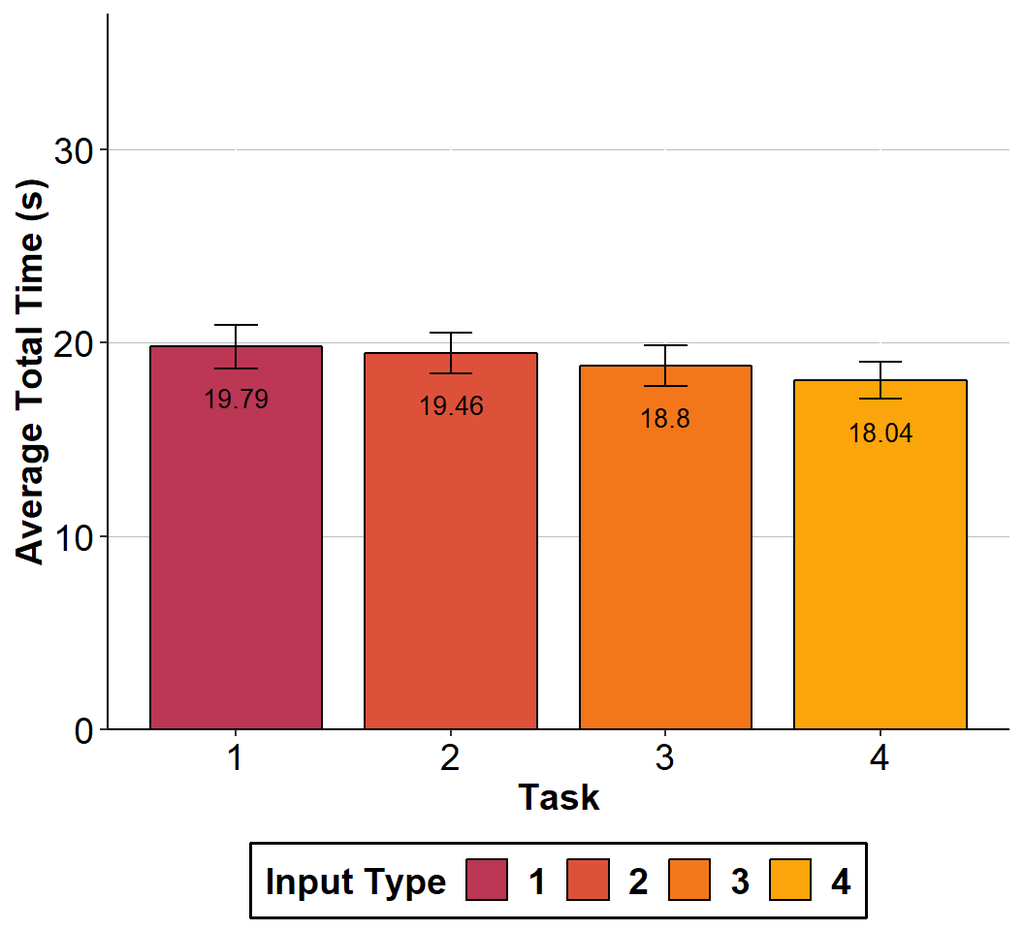

```r
ggplot(data.stats, aes(x=block, y=mTT/1000, fill=block)) +
  geom_bar(aes(group=block), position = position_dodge(.8), colour="black", stat="identity", width=.8) +
  geom_errorbar(aes(ymin = clTT/1000, ymax = cuTT/1000, group= block), width = 0.2, size = .5, position = position_dodge(.8)) +
  geom_text(aes(label=round(mTT/1000,digits=2), group= block), size = 3.5, position = position_dodge(.8), vjust = 3, alignment="center") +
  scale_x_discrete(name="Task") +
  scale_y_continuous(name="Average Total Time (s)", limits = c(0, 37), minor_breaks = 5, expand = c(0, 0)) +
  scale_fill_viridis(option="inferno", begin=0.5, end = .8, discrete = TRUE) +
  #scale_fill_manual(values=c("#DF5E28", "#F6C584")) +
  labs(fill = "Input Type") +
  theme(legend.position = "bottom",
        legend.box.background = element_rect(size=1, color="black"),
        legend.background = element_rect(size = 0.3, linetype = "solid", colour = "black"),
        panel.background = element_blank(),
        panel.border = element_blank(),
        axis.line = element_line(),
        axis.title = element_text(family="Helvetica", face="bold", colour="black", size="14"),
        axis.text = element_text(family="Helvetica", colour="black", size="14"),
        panel.grid.major.y = element_line( size = .1, color = "grey"),
        legend.title = element_text(family="Helvetica", face="bold", colour="black", size="14"),
        legend.text = element_text(family="Helvetica", face="bold", colour="black", size="14"))
```

## 4.2 Effects of Input Type, Task Type and Block

### 4.2.1 Normality Check

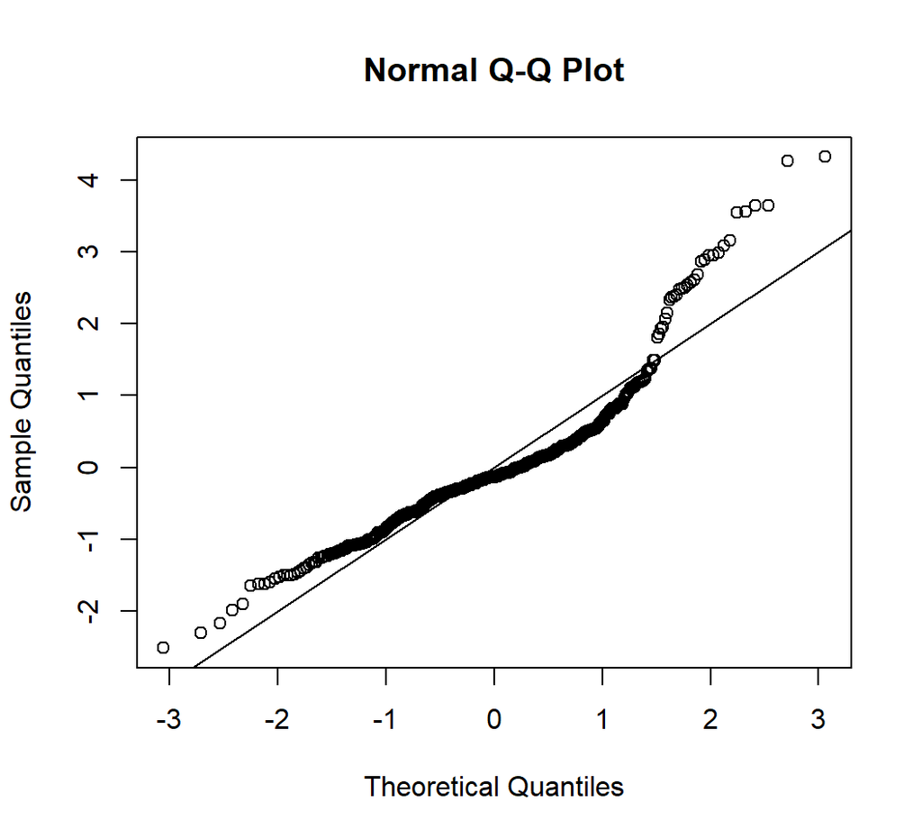

```r
m <- aov(meanTotalTime ~ taskType*inputType*block, data=data.long)
pander(normalCheck(m))
```

Shapiro-Wilk normality test

data: res W = 0.89682, p-value < 2.2e-16

Shapiro-Wilk normality test: `res`

| Test statistic | P value |
| --- | --- |
| 0.8968 | 8.061e-17 * * * |

The data is not normally distributed.

### 4.2.2 Box-Cox Transformation

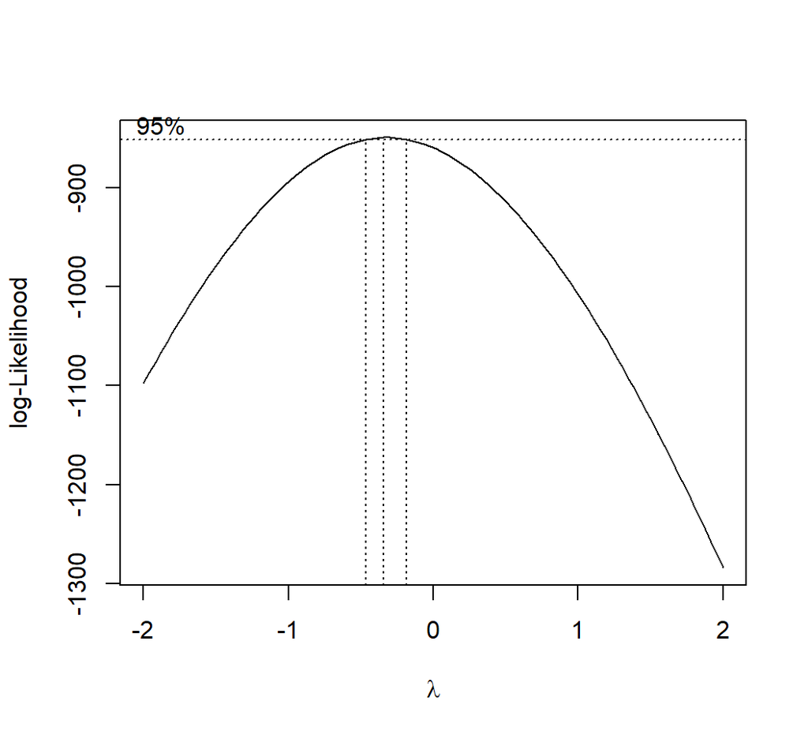

```r
boxcox(meanTotalTime ~ inputType*taskType*block, data=data.long, plotit=T)
```

An effective lambda value is -0.25.

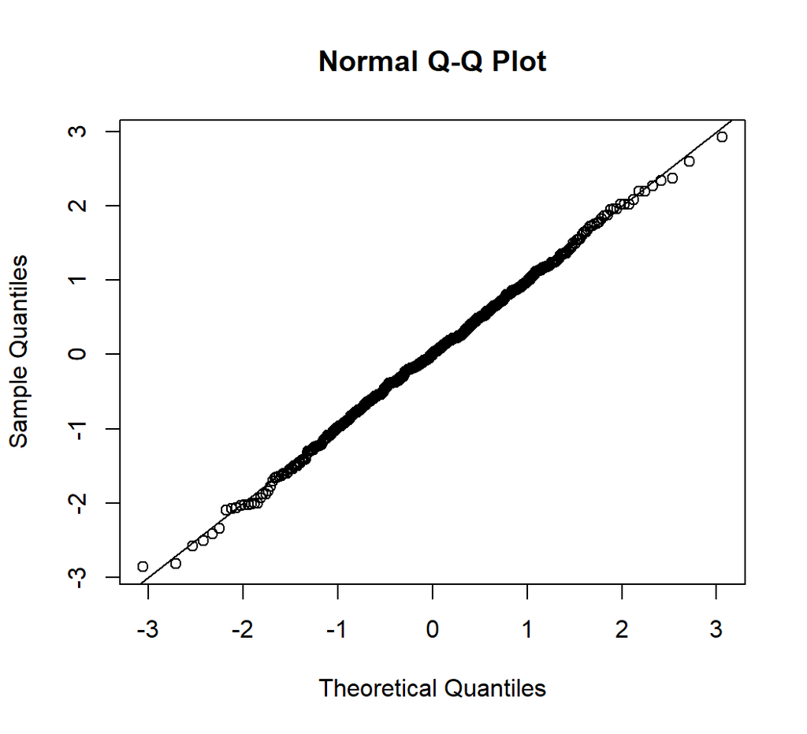

```r
datatr = data.long %>%
    mutate(meanTotalTime = meanTotalTime^(-0.25))

m <- aov(meanTotalTime ~ taskType*inputType*block, data=datatr)
pander(normalCheck(m))
```

Shapiro-Wilk normality test

data: res W = 0.99838, p-value = 0.9537

Shapiro-Wilk normality test: `res`

| Test statistic | P value |
| --- | --- |
| 0.9984 | 0.9537 |

### 4.2.3 Repeated measures ANOVA on transformed data

```r
anova = ezANOVA(datatr, dv=.(meanTotalTime), wid=.(participantNo), within=.(inputType,taskType,block), detailed=TRUE)

# kable(anova$`Mauchly's Test for Sphericity`)
# kable(anova$`Sphericity Corrections`)
# kable(anova$ANOVA)
anova_apa = anova_apa(anova, sph_corr ="gg", es = "ges", print=FALSE)
input = anova_apa$text[2]
task = anova_apa$text[3]
inter = anova_apa$text[4]
kable(anova_apa)
```

| effect | text |
| --- | --- |
| (Intercept) | F(1, 27) = 9823.46, p < .001, getasq = .99 |
| inputType | F(1, 27) = 118.38, p < .001, getasq = .38 |
| taskType | F(1, 27) = 189.05, p < .001, getasq = .52 |
| block | F(2.32, 62.57) = 4.40, p = .012, getasq < .01 |
| inputType:taskType | F(1, 27) = 38.24, p < .001, getasq = .08 |
| inputType:block | F(3, 81) = 1.68, p = .177, getasq < .01 |
| taskType:block | F(3, 81) = 1.30, p = .281, getasq < .01 |
| inputType:taskType:block | F(3, 81) = 0.16, p = .925, getasq < .01 |

Main effect of block, no interactions with other variables.

### 4.2.4 Post-hoc analysis with Tukey HSD

```r
t <- TukeyHSD(m)
kable(t$block)
```

|  | diff | lwr | upr | p adj |
| --- | --- | --- | --- | --- |
| 2-1 | 0.0000705 | -0.0023549 | 0.0024959 | 0.9998487 |
| 3-1 | 0.0011358 | -0.0012896 | 0.0035613 | 0.6222157 |
| 4-1 | 0.0013900 | -0.0010354 | 0.0038154 | 0.4516729 |
| 3-2 | 0.0010653 | -0.0013601 | 0.0034908 | 0.6694145 |
| 4-2 | 0.0013195 | -0.0011059 | 0.0037449 | 0.4980663 |
| 4-3 | 0.0002542 | -0.0021713 | 0.0026796 | 0.9930905 |

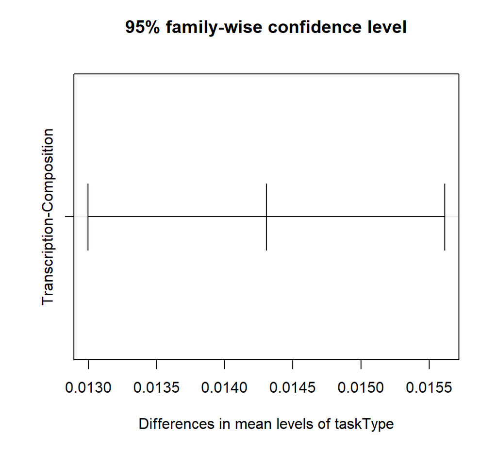

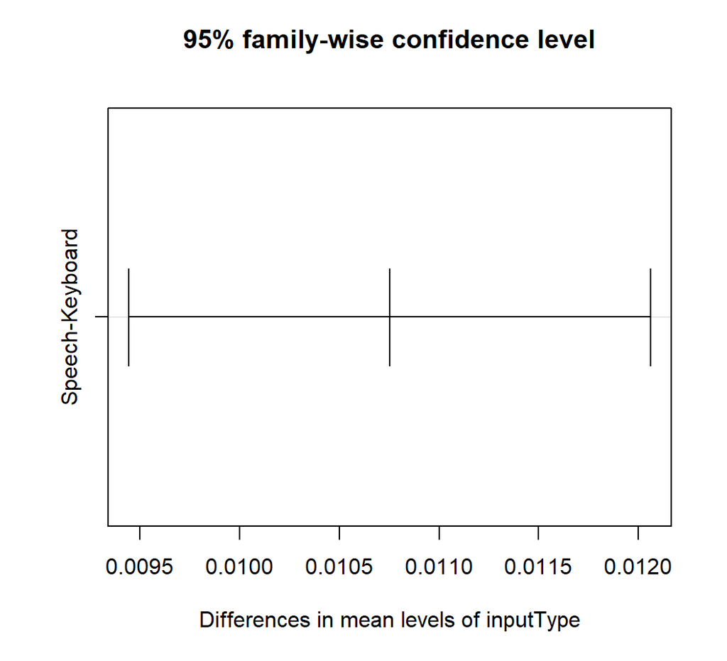

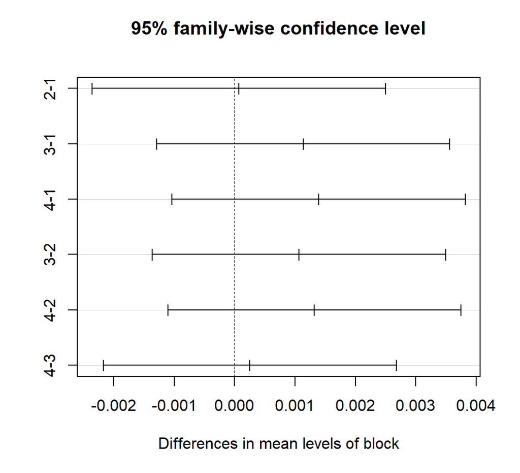

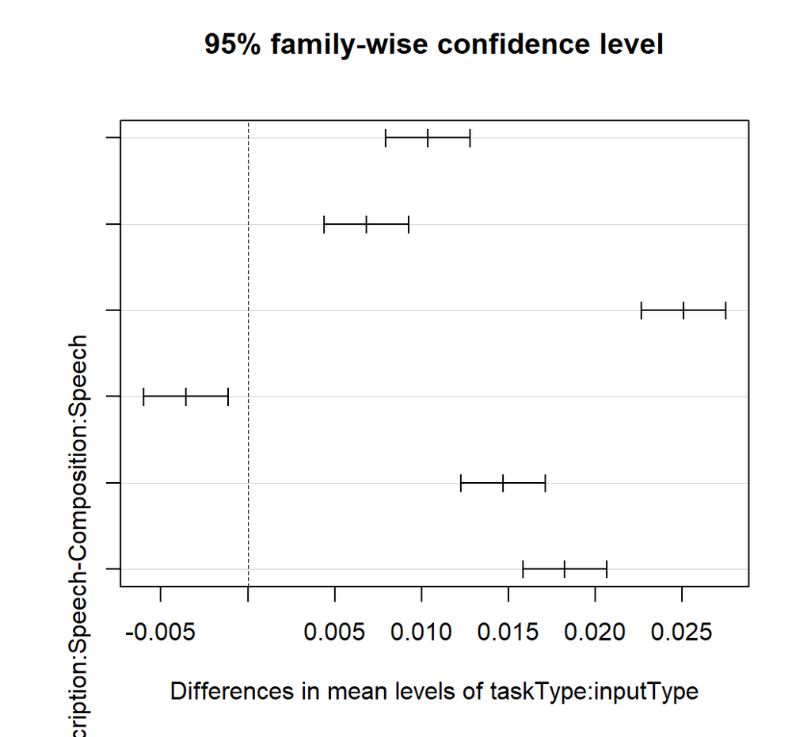

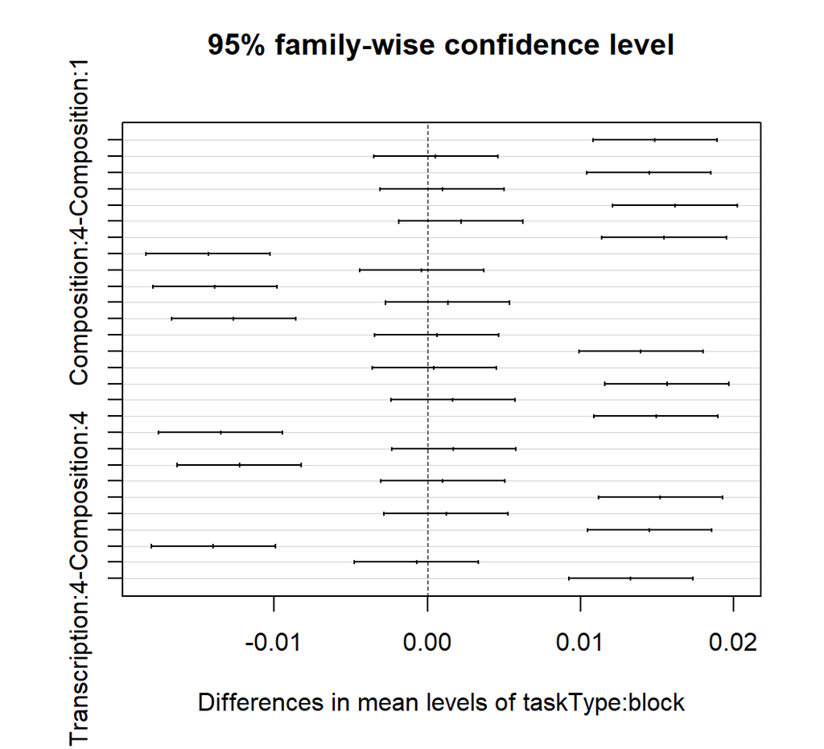

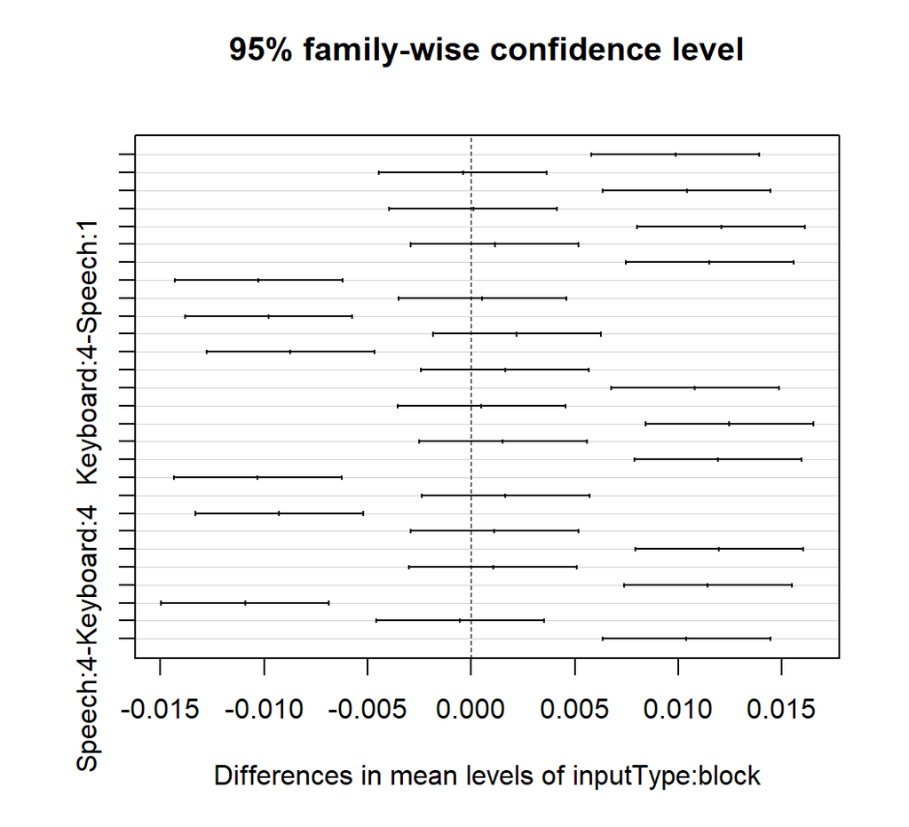

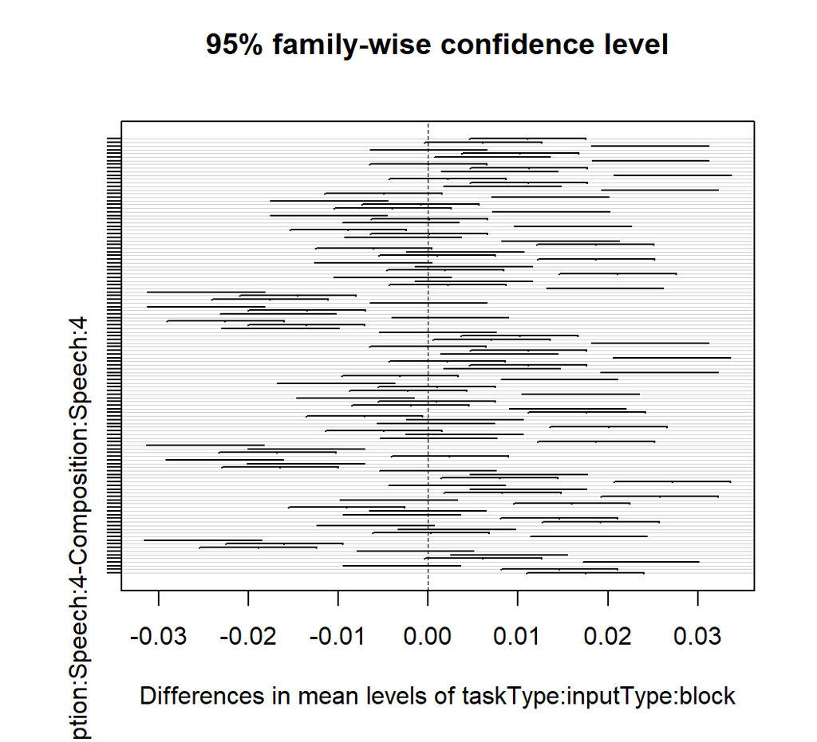

```r
plot(t)
```

# 5 Words per Minute

## 5.1 Effects of Input Type and Task Type and Block

### 5.1.1 Normality Check

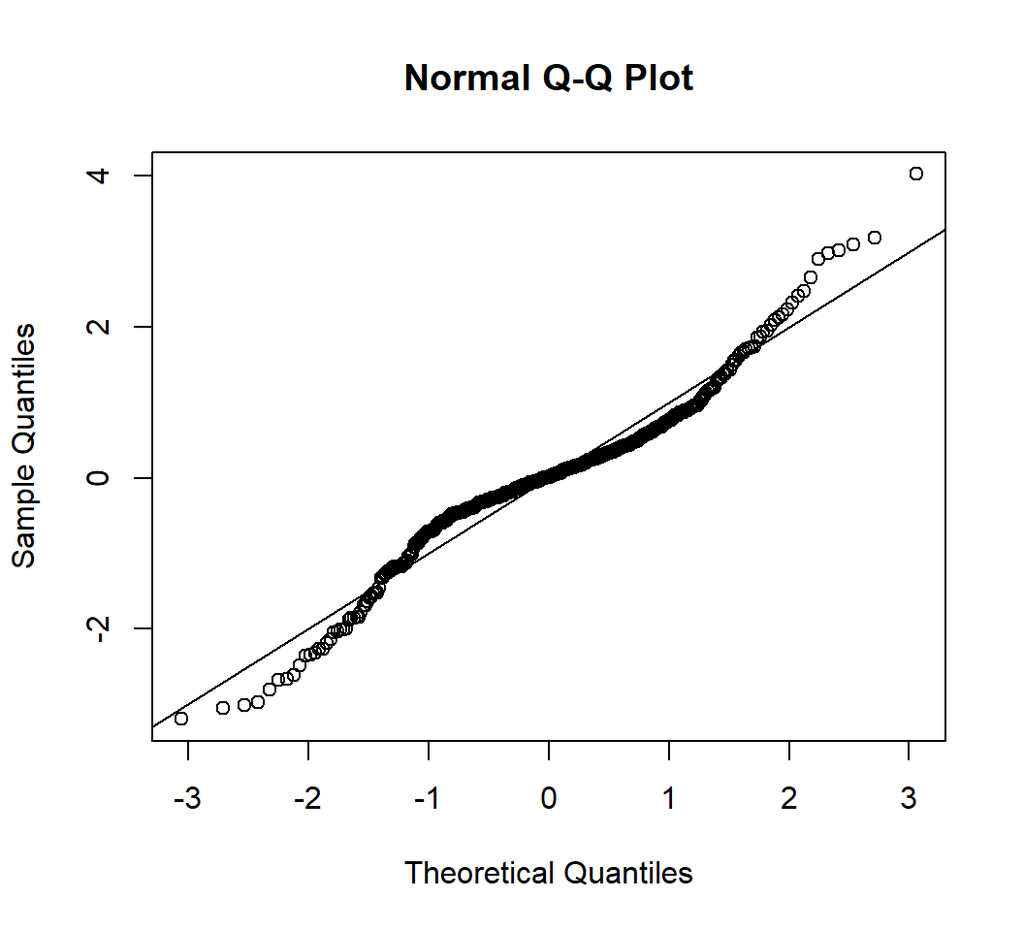

```r
m <- aov(meanWpm ~ taskType*inputType*block, data=data.long)
pander(normalCheck(m))
```

Shapiro-Wilk normality test

data: res W = 0.95549, p-value = 2.235e-10

Shapiro-Wilk normality test: `res`

| Test statistic | P value |
| --- | --- |
| 0.9555 | 2.235e-10 * * * |

The data is not normally distributed.

### 5.1.2 Box-Cox Transformation

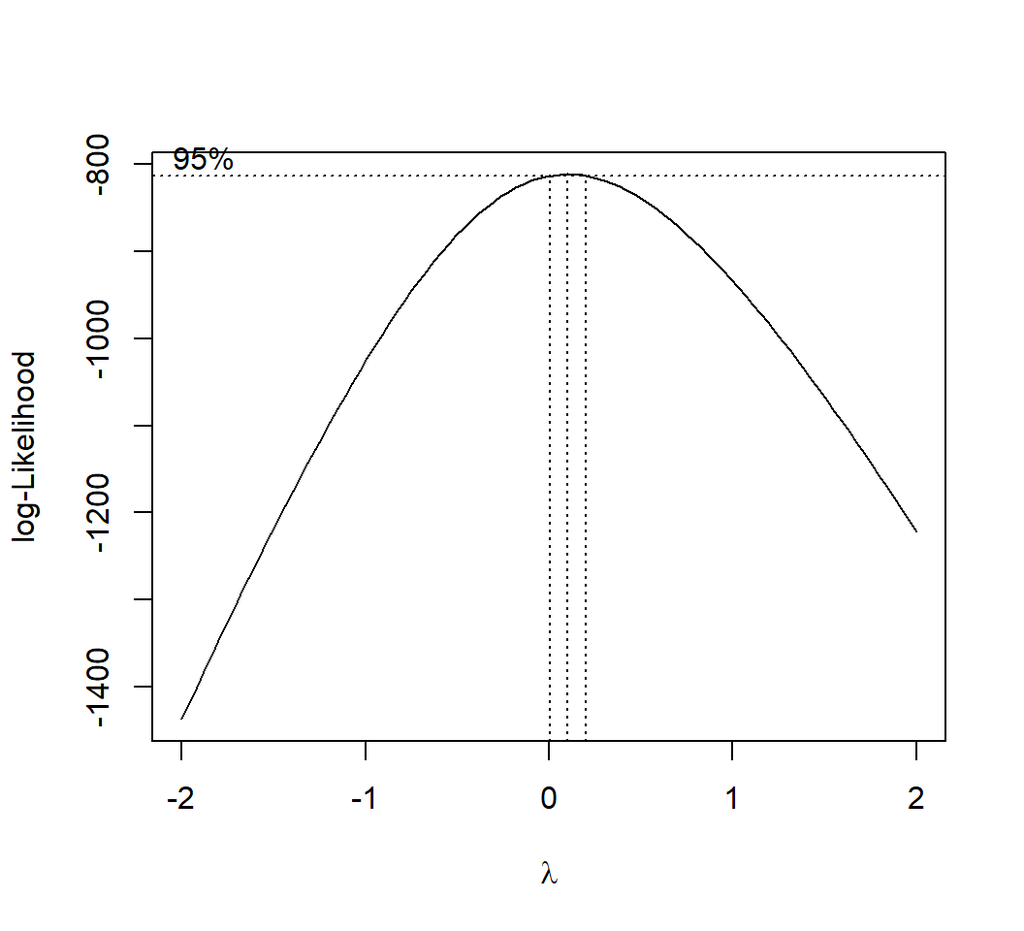

```r
boxcox(meanWpm ~ inputType*taskType*block, data=data.long, plotit=T)
```

An effective lambda value is 0.1

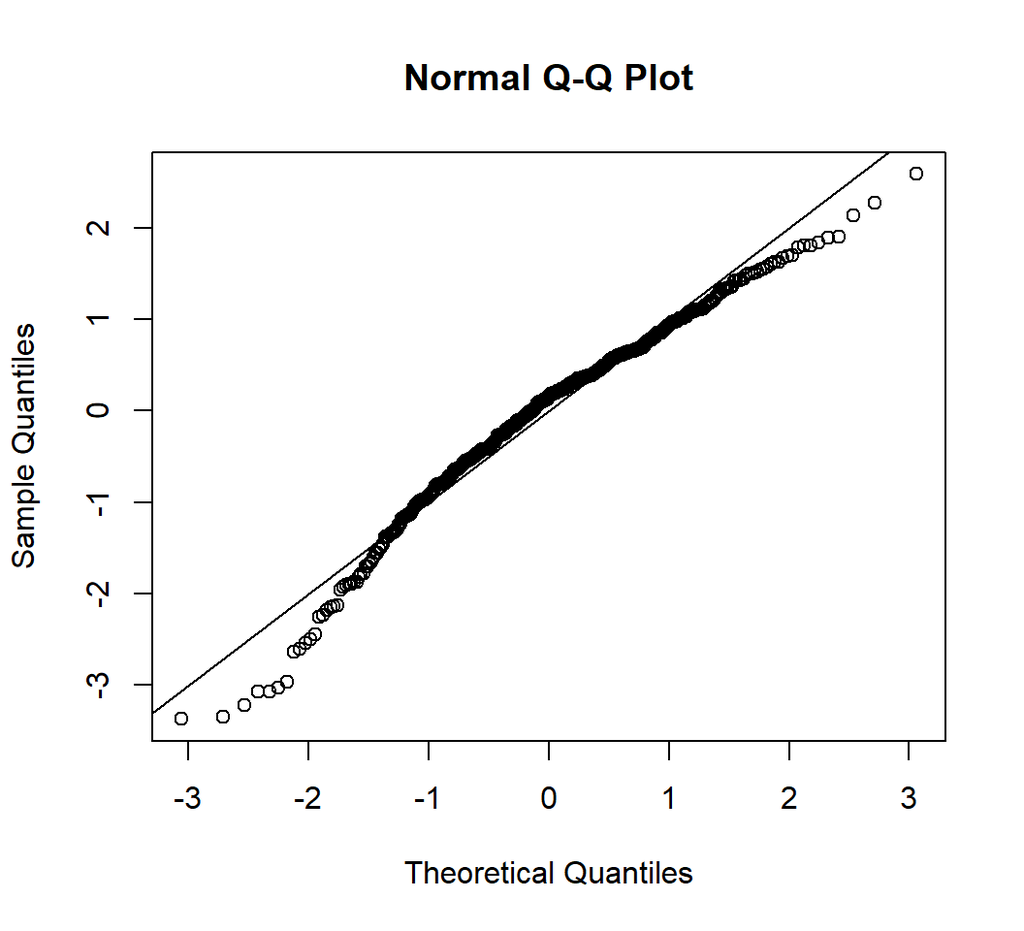

```r
datatr = data.long %>%
    mutate(meanWpm = meanWpm^(0.1))

m <- aov(meanWpm ~ taskType*inputType*block, data=datatr)
pander(normalCheck(m))
```

Shapiro-Wilk normality test

data: res W = 0.97137, p-value = 1.103e-07

Shapiro-Wilk normality test: `res`

| Test statistic | P value |
| --- | --- |
| 0.9714 | 1.103e-07 * * * |

### 5.1.3 Repeated measures ANOVA on transformed data

```r
anova = ezANOVA(datatr, dv=.(meanWpm), wid=.(participantNo), within=.(inputType,taskType,block), detailed=TRUE)

anova_apa = anova_apa(anova, sph_corr ="gg", es = "ges", print=FALSE)
input = anova_apa$text[2]
task = anova_apa$text[3]
inter = anova_apa$text[4]
kable(anova_apa)
```

| effect | text |
| --- | --- |
| (Intercept) | F(1, 27) = 126150.20, p < .001, getasq > .99 |
| inputType | F(1, 27) = 469.53, p < .001, getasq = .81 |
| taskType | F(1, 27) = 77.37, p < .001, getasq = .22 |
| block | F(3, 81) = 0.50, p = .681, getasq < .01 |
| inputType:taskType | F(1, 27) = 0.54, p = .470, getasq < .01 |
| inputType:block | F(3, 81) = 0.46, p = .714, getasq < .01 |
| taskType:block | F(3, 81) = 1.76, p = .160, getasq < .01 |
| inputType:taskType:block | F(3, 81) = 1.24, p = .301, getasq < .01 |

No effect of block on WPM

# 6 Corrected Error Rate

## 6.1 Effects of Input Type and Task Type and Block

### 6.1.1 Normality Check

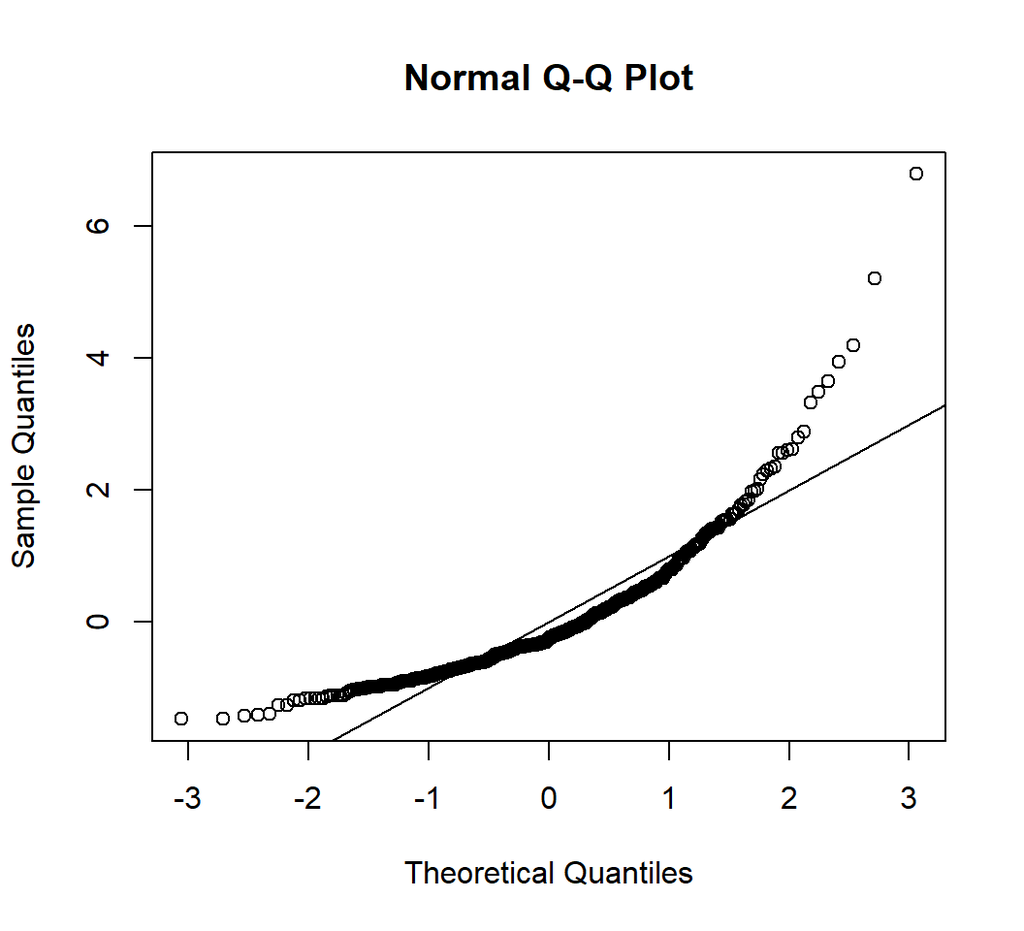

```r
m <- aov(mean_cer ~ taskType*inputType*block, data=data.long)
pander(normalCheck(m))
```

Shapiro-Wilk normality test

data: res W = 0.84373, p-value < 2.2e-16

Shapiro-Wilk normality test: `res`

| Test statistic | P value |
| --- | --- |
| 0.8437 | 1.226e-20 * * * |

The data is not normally distributed.

### 6.1.2 ANOVAs in ART Data

```r
a = art(mean_cer ~ taskType*inputType*block + (1|participantNo), data=data.long)
anova(a)
```

```
## Analysis of Variance of Aligned Rank Transformed Data
##
## Table Type: Analysis of Deviance Table (Type III Wald F tests with Kenward-Roger df)
## Model: Mixed Effects (lmer)
## Response: art(mean_cer)
##
##                                    F Df Df.res     Pr(>F)
## 1 taskType                 18.188196  1    405 2.4932e-05 ***
## 2 inputType                 4.972544  1    405    0.02630   *
## 3 block                     0.873413  3    405    0.45486
## 4 taskType:inputType        2.536184  1    405    0.11204
## 5 taskType:block            1.187042  3    405    0.31434
## 6 inputType:block           0.091063  3    405    0.96494
## 7 taskType:inputType:block  0.628790  3    405    0.59676
## ---
## Signif. codes:   0 '***' 0.001 '**' 0.01 '*' 0.05 '.' 0.1 ' ' 1
```

No effect of block.

# 7 Uncorrected Error Rate

## 7.1 Effects of Input Type and Task Type and Block

### 7.1.1 Normality Check

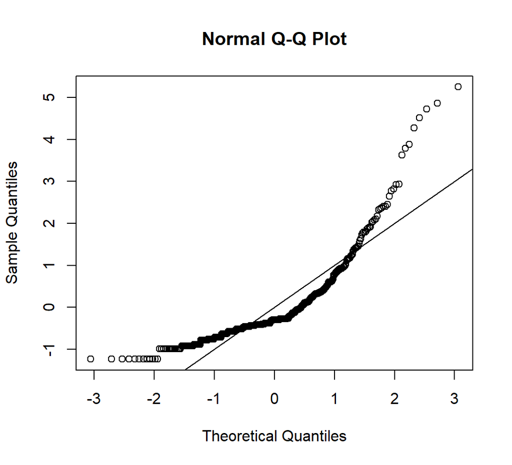

```r
m <- aov(mean_uer ~ taskType*inputType*block, data=data.long)
pander(normalCheck(m))
```

Shapiro-Wilk normality test

data: res W = 0.79132, p-value < 2.2e-16

Shapiro-Wilk normality test: `res`

| Test statistic | P value |
| --- | --- |
| 0.7913 | 1.504e-23 * * * |

The data is not normally distributed.

### 7.1.2 ANOVAs in ART Data

```r
a = art(mean_uer ~ taskType*inputType*block + (1|participantNo), data=data.long)
anova(a)
```

```
## Analysis of Variance of Aligned Rank Transformed Data
##
## Table Type: Analysis of Deviance Table (Type III Wald F tests with Kenward-Roger df)
## Model: Mixed Effects (lmer)
## Response: art(mean_uer)
##
##                                   F Df Df.res     Pr(>F)
## 1 taskType                  2.51452  1    405  0.1135825
## 2 inputType                17.71362  1    405 3.1653e-05 ***
## 3 block                     1.62633  3    405  0.1826648
## 4 taskType:inputType        7.17186  1    405  0.0077069  **
## 5 taskType:block            0.95589  3    405  0.4135411
## 6 inputType:block           2.45588  3    405  0.0626349   .
## 7 taskType:inputType:block  0.99131  3    405  0.3967850
## ---
## Signif. codes:   0 '***' 0.001 '**' 0.01 '*' 0.05 '.' 0.1 ' ' 1
```

No effect of block.